# R49 Results

[figure not shown]

[figure not shown]

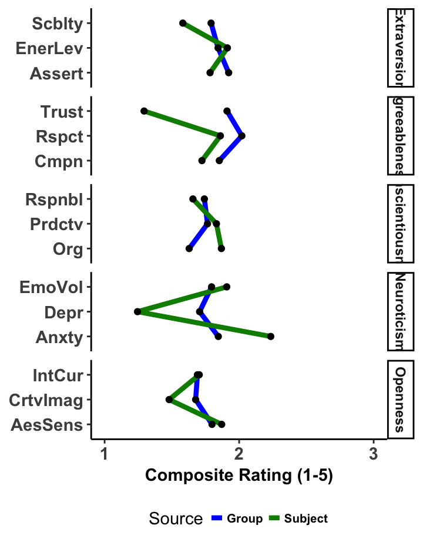

[figure not shown]

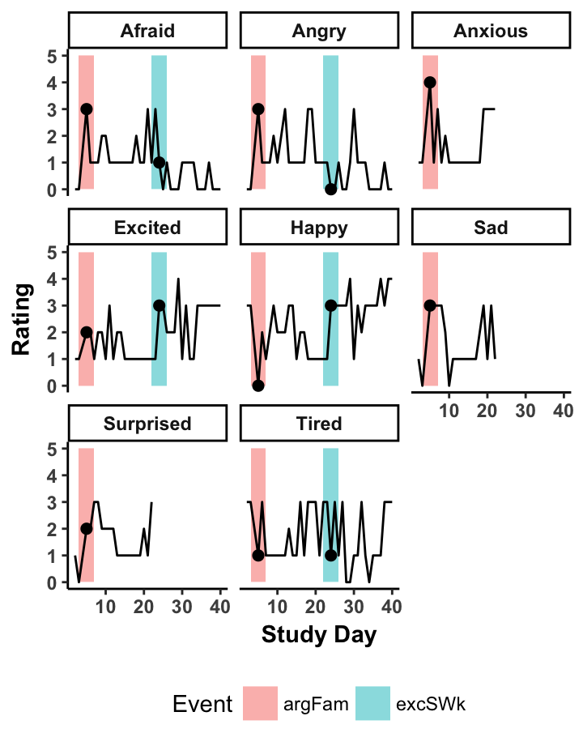

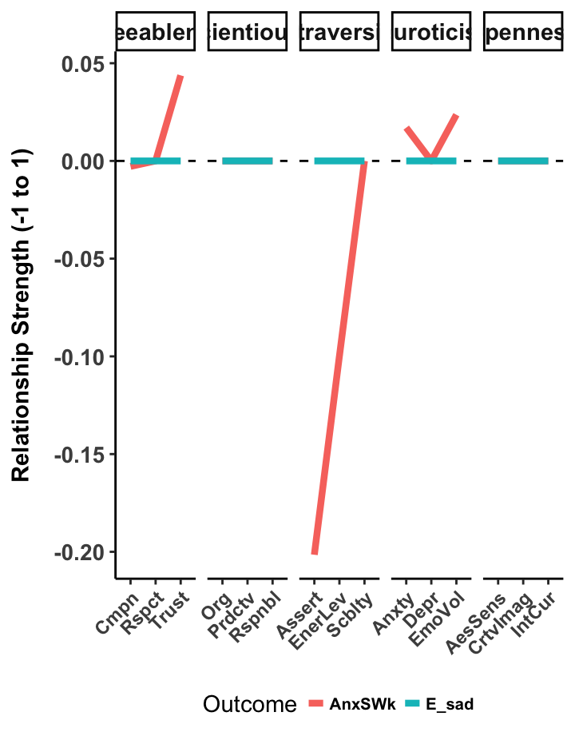

# Home

### **Extraversion Percentile**

[interactive chart not shown]

### **Agreeableness Percentile**

[interactive chart not shown]

### **Conscientiousness Percentile**

[interactive chart not shown]

### **Neuroticism Percentile**

[interactive chart not shown]

### **Openness Percentile**

[interactive chart not shown]

**Welcome to your personalized results**

Before we dive into your results, though, you should take a minute to learn a little more about the surveys you completed. In each survey, we asked you to do a number of different things from generating a word related to others to reporting what you were doing. If you’d like to learn more, these are summarized below (Measures).

Once your ready, click the “What’s Next” tab to see what you are going to do in the future.

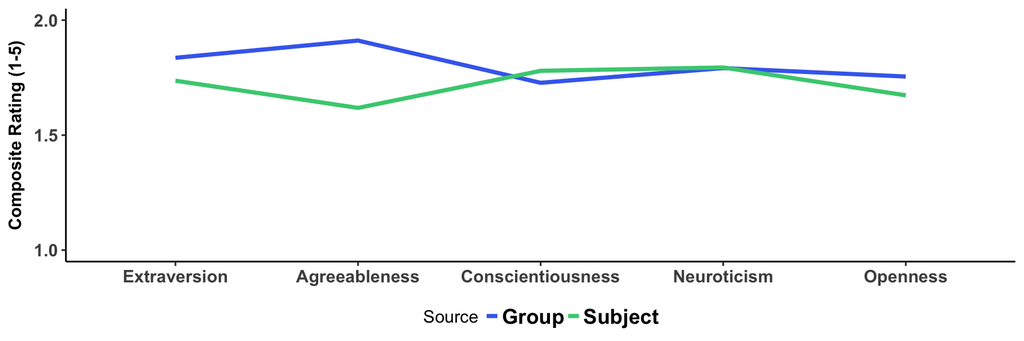

### What’s Next?

The next step is to review your responses from the surveys you took, so you can use them to improve your life.

As you go through your results, we challenge you to (1) think about things that do or do not surprise you and to (2) think about strategies you can use to tackle these. We will provide you with a set of recommended strategies based on your personality, but ultimately, the strategies you use should be tailored to your goals and desires.

**This document procedes in 4 parts:**

1. First, we provide you with a broad overview of your personality relative to others in the study.

2. Then we provide you with a snapshot of your month in terms of the events you encountered and the emotions your reported while experiencing those events.  
3. Then we look at specific patterns of behaviors that were related to your loneliness.  
4. Finally, we provide you with a set of tailored strategies based on your personality that will help you to target your loneliness.

As you move into the next phase of this study, we invite you to refer back to this document frequently for guidance.

### Measures

|  |  | Description |
| --- | --- | --- |
| 1 | **Remote Associates Test**: | The first task is called the Remote Associates Test (RAT). In this test, you are given three words, like “swiss / cottage / cake” and asked to generated a 4th word related to those 3, like “cheese.” T… |
| 2 | **Personality and Emotions**: | Second, we asked you to respond to a subset of 10 personality items from a larger subset of 60 from the Big 5 Inventory 2 (BFI-2; see the Overview page for more details on the prompts you responded to… |
| 3 | **(Psychological) Situations**: | Third, you responded to eight items that represent the so-called DIAMONDs model of situations. The idea behind this model is that we can break down the “objective” situations we encounter (e.g. in cla… |
| 4 | **Common Situations**: | Fourth, we had you check off things that had just happened to you like feeling tired, doing schoolwork, or surfing the web. We asked you these, so you could get a realistic sample of how you actually … |
| 5 | **Memory**: | Fifth, sometimes, but not always, we asked you to remember words from the RAT. We did this in the hopes that we might be able to help you better understand times when your memory is more alert and att… |

# Overview

### Summary

Below you see a summary of your personality. On the left, you see a graph of your personality relative to other people in the study. The green line represents you while the blue line represents everyone else. On the right you see a list of items you responded to during the study that were used to calculate the values you see on the left.

### Descriptions

|  |  | Description |
| --- | --- | --- |
| 1 | **Extraversion:** | Extraverison has gained considerable attention in popular media as the difference between people who like to spend time with lots of others and those who would rather hang out at home with a cat and a… |
| 2 | **Agreeableness:** | Agreeableness is often thought of as the trait of compliance. Although Agreeable people do tend to avoid conflict, but they also tend to be warmer, more empathetic, and more positive than others. Agre… |
| 3 | **Conscientiousness:** | Conscientiousness often aligns with characteristics typically thought of as Type A. Conscientious people make plans and stick to them. They are organized and think things through. They are reliable, p… |
| 4 | **Emotional Stability (Neuroticism):** | Emotional Stability is somewhat like it sounds. Emotionally stable people are able to regulate (and not just repress) their emotions. They seem relaxed and their emotions are not easily swayed by smal… |
| 5 | **Openness:** | Openness is the sort of the hipster trait. People who are high in Openness tend to be intelligent, curious, open-minded, and politically liberal. They are willing to try anything and have flexibility … |

### Personality Profile

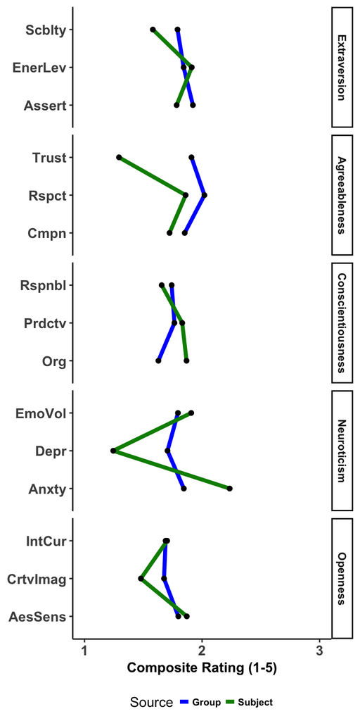

### Items

| Trait | Facet | ItemText |
| --- | --- | --- |
| Extraversion | Sociability | Is outgoing, sociable. |
|  |  | Is talkative. |
|  |  | Tends to be quiet. |
|  |  | Is sometimes shy, introverted. |
|  | Assertiveness | Has an assertive personality. |
|  |  | Is dominant, acts as a leader. |
|  |  | Finds it hard to influence people. |
|  |  | Prefers to have others take charge. |
|  | Energy Level | Is full of energy. |
|  |  | Shows a lot of enthusiasm. |
|  |  | Rarely feels excited or eager. |
|  |  | Is less active than other people. |
| Agreeableness | Compassion | Is compassionate, has a soft heart. |
|  |  | Is helpful and unselfish with others. |
|  |  | Feels little sympathy for others. |
|  |  | Can be cold and uncaring. |
|  | Respectfulness | Is respectful, treats others with respect. |
|  |  | Is polite, courteous to others. |
|  |  | Starts arguments with others. |
|  |  | Is sometimes rude to others. |
|  | Trust | Has a forgiving nature. |
|  |  | Assumes the best about people. |
|  |  | Tends to find fault with others. |
|  |  | Is suspicious of others’ intentions. |
| Conscientiousness | Organization | Is systematic, likes to keep things in order. |
|  |  | Keeps things neat and tidy. |
|  |  | Tends to be disorganized. |
|  |  | Leaves a mess, doesn’t clean up. |
|  | Productiveness | Is efficient, gets things done. |
|  |  | Is persistent, works until the task is finished. |
|  |  | Tends to be lazy. |
|  |  | Has difficulty getting started on tasks. |
|  | Responsibility | Is dependable, steady. |
|  |  | Is reliable, can always be counted on. |
|  |  | Can be somewhat careless. |
|  |  | Sometimes behaves irresponsibly. |
| Neuroticism | Anxiety | Can be tense. |
|  |  | Worries a lot. |
|  |  | Is relaxed, handles stress well. |
|  |  | Rarely feels anxious or afraid. |
|  | Depression | Often feels sad. |
|  |  | Tends to feel depressed, blue. |
|  |  | Stays optimistic after experiencing a setback. |
|  |  | Feels secure, comfortable with self. |
|  | Emotional Volatility | Is moody, has up and down mood swings. |
|  |  | Is temperamental, gets emotional easily. |
|  |  | Is emotionally stable, not easily upset. |
|  |  | Keeps their emotions under control. |
| Openness | Intellectual Curiosity | Is curious about many different things. |
|  |  | Is complex, a deep thinker. |
|  |  | Avoids intellectual, philosophical discussions. |
|  |  | Has little interest in abstract ideas. |
|  | Aesthetic Sensitivity | Is fascinated by art, music, or literature. |
|  |  | Values art and beauty. |
|  |  | Has few artistic interests. |
|  |  | Thinks poetry and plays are boring. |
|  | Creative Imagination | Is inventive, finds clever ways to do things. |
|  |  | Is original, comes up with new ideas. |
|  |  | Has little creativity. |
|  |  | Has difficulty imagining things. |

### Top Percentile #1: Anxty

[interactive chart not shown]

### Top Percentile #2: EmoVol

[interactive chart not shown]

### Bottom Percentile #1: Trust

[interactive chart not shown]

### Bottom Percentile #2: Depr

[interactive chart not shown]

# Summary of Your Month

### Loneliness Frequency

4

### Tired Frequency

9

### How did you feel?

Another question to ask is how different events impacted your emotions. Here you see a few events that did not happen to you frequently as well as your emotions when you reported them. Do you see any notable ups or downs that occur with these events.

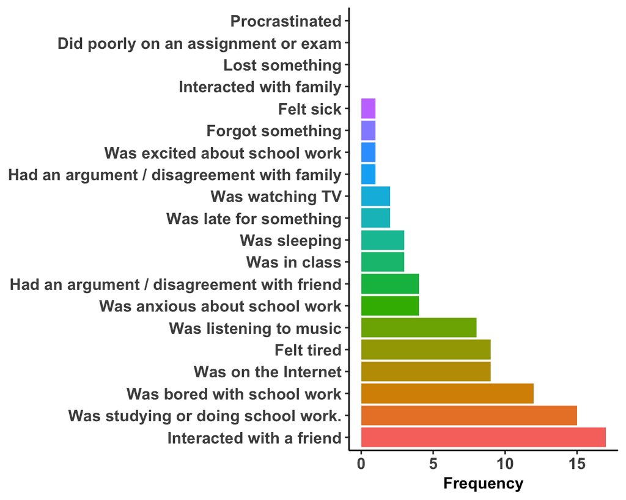

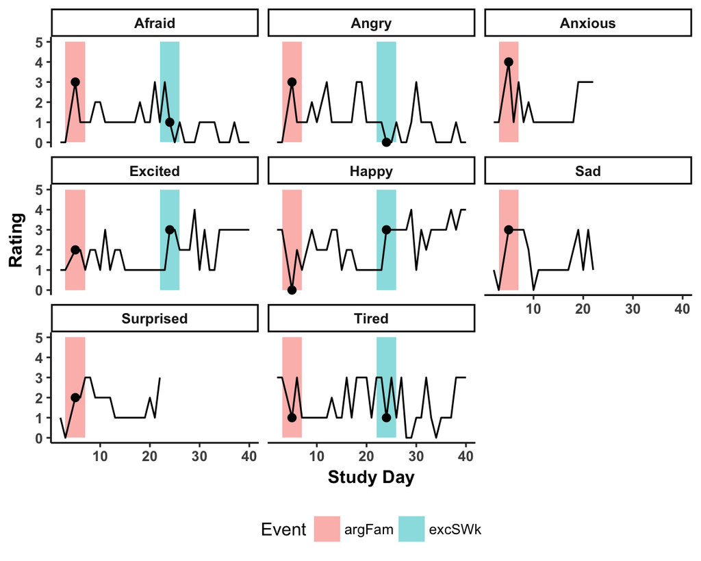

# Individualized Results

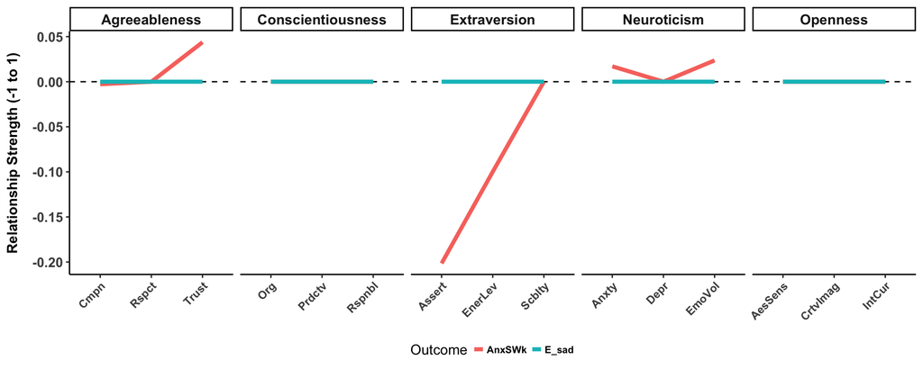

**1. Concurrent:**  
Concurrent patterns mean that two things happen at the same time. This could mean that you are sad or disorganized *while* you are lonely. These are important because they help us to identify things that we experience at the same time, which we often are not aware of.

For you, we see that your loneliness was independent of your other behaviors – that is, you did not report any behaviors that tended to also occur while you were lonely.

### Loneliness-Cmpn Link

0

### Loneliness-Rspct Link

0

### Loneliness-Trust Link

0

### Loneliness-Org Link

0

# Your Personalized Strategies

### Procrastination-Organization “While” Link

0

### **Loneliness-Emotional Volatility “While” Link**

0

### **Procrastination –> Organization “from” Link**

0

### **Loneliness–>Emotional Volatility “from” Link**

0.16

### **Procrastination <– Organization “to” Link**

0.08

### **Loneliness <– Emotional Volatility “to” Link**

0.96